# Stationarity

Intuitively, stationarity means that the statistical properties of the process do not change over time.

### **Strong Stationarity**

Time series is strong stationary given that the unconditional joint probability distribution (probability of two things happening at the same time) does not change when shifted in time. At a window in time a, the distribution is the same as at a window in time b.

### **Weak Stationarity**

The entire distyribution does not need to be the same per se. But some condtions must be met. **Weak is sufficient**.

- Mean $\mu$ of the time series is constant over time
- Variance $\sigma$ of the series is constant over time
- There should be no seasonal component

### **Trend-Stationary**

In the statistical analysis of time series, a trend-stationary process is a stochastic process from which an underlying trend (function solely of time) can be removed, leaving a stationary process. The trend does not have to be linear.

### **Types of stationarity tests**

#### **Augmented Dickey-Fuller Test (ADF)**

*coming soon*

#### **Phillips-Perron Test**

*coming soon*

#### **Kwiatkowski-Phillips-Schmidt-Shin (KPSS) test**

*coming soon*

## **Unit Root**

$$\gamma_t = \mu + \varphi \gamma_{t-1} + \varepsilon_t$$
Which can also be represented as an MA($\infty$) model:
$$= \varphi^ty_0 + \sum_{t-1}{k=0}\ \varphi^k + \varepsilon_{t-k}$$
The variance of our time series:
$$var(q_t) = \sigma^2 [\varphi^0 + \varphi^2 + \varphi^4, ..., \varphi^{2(t-1)}$$
The expected value of our time series:
$$E(y_t) = \varphi^t y_0$$

### **Stationarity Refuted: $|\varphi| > 1$**

Now, suppose that $\varphi = 1.5$. The value of yesterday for $\gamma$ was 100 but the $\mu$ is 0. In light of the equation for expected value:
$$E(y_t) = \varphi^t y_0$$
When the exponent t tends to $\infty$, our expected value will skyrocket to $\pm \infty$. We refute stationarity because the mean changes over time lags. The effects of the past evolve over time. There is no constant relationship between y and x (being time lags). E.g., smaller brands in emerging markets.

### **Stationarity refuted: (Unit root) $|\varphi| = 1$**

A time series has a unit root if $\varphi =$ 1 or -1. The mean of the time series stays constant, however, variance $\sigma^2$ changes over time.
$$var(q_t) = \sigma^2 [\varphi^0 + \varphi^2 + \varphi^4, ..., \varphi^{2(t-1)}]$$
$$var(q_t) = \sigma^2 [1^0 + 1^2 + 1^4, ..., 1^{2(t-1)}$$
Which translates to…
$$var(q_t) = t\sigma^2$$
This means that variance will increase as time lags increase. Thus, variance will not be constant. Shocks have an explosive effect over time. It’s rather rare in marketing with the exception of stocks of products.

### **Manually Testing for Stationarity**

We can manually calculate the coefficients. Let’s look at the initial difference equation of an AR(2) model as an example:
$$y_t = \mu + \varphi y_{t-1} + \varphi_2 y_{t-2} \varepsilon_t$$
This corresponds to…
$$L^2y_t = y_{t-2}$$
(1) Replace $y_{t-1}$ and $y_{t-2}$ with $Ly_t$ and $L^2y_t$:
$$y_t = \mu + \varphi_1Ly_t + \varphi_2L^2y_t + \varepsilon_t$$
(2) rewrite by collecting all terms with $y_t$ on the left hand side of the equation:
$$y_t - \varphi_1Ly_t + \varphi_2L^2y_t = \mu + \varepsilon_t$$
(3) factor out the $y_t$ because it appears three times:
$$(1 - \varphi_1L - \varphi_2L^2)y_t = \mu + \varepsilon_t$$
(4) stable or explosive? We can find out by looking at
$$(1 - \varphi_1L - \varphi_2L^2)$$
(5) the characteristic polynomial equation of it is used. The best way to see what is going on is to put them next to each other. Coefficients remain exactly the same but L operators are replaced by lambdas. Also, we have reversed the powers.
$$(1*L^0 - \varphi_1L^1 - \varphi_2L^2)$$
$$(\lambda^2 * 1 - \varphi_1 \lambda^1 - \varphi_2\lambda^0)$$
Where does this come from? It comes from the AR(2) model and MA($\infty$) theorem. But how does the characteristic equation tell us whether the proces $y_t$ is stable? We set it to zero to make it an actual equation:
$$(1*L^0 - \varphi_1L^1 - \varphi_2L^2) = 0$$
The values for $\lambda_i$ will determine whether $y_t$ is a stable (stationary) process or not. If either of these values is above 1, then the process is not stable.

```r
library(FitAR)
library(forecast)
library(tseries)
library(gplots)
library(aTSA)
library(astsa)
```

```r
food.df <- read.csv("../SLIM0405DataSeries.csv")
```

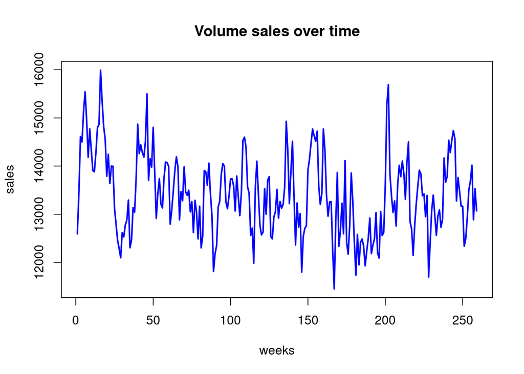

```r
plot(food.df[,c(1)],food.df[,c(2)], type="l", col="blue", lwd=2, xlab="weeks", ylab="sales", main="Volume sales over time")
```

### **Augmented Dickey-Fuller Test (ADF)**

Dickey-Fuller test suggests that the time series has drift but no trend.

```r
adf.test(food.df[,c(2)])
```

```
## Augmented Dickey-Fuller Test
## alternative: stationary
##
## Type 1: no drift no trend
##      lag    ADF p.value
## [1,]   0 -0.349   0.543
## [2,]   1 -0.365   0.539
## [3,]   2 -0.419   0.523
## [4,]   3 -0.395   0.530
## [5,]   4 -0.488   0.504
## Type 2: with drift no trend
##      lag   ADF p.value
## [1,]   0 -6.97    0.01
## [2,]   1 -6.50    0.01
## [3,]   2 -5.56    0.01
## [4,]   3 -5.05    0.01
## [5,]   4 -5.18    0.01
## Type 3: with drift and trend
##      lag   ADF p.value
## [1,]   0 -7.28    0.01
## [2,]   1 -6.82    0.01
## [3,]   2 -5.80    0.01
## [4,]   3 -5.28    0.01
## [5,]   4 -5.37    0.01
## ----
## Note: in fact, p.value = 0.01 means p.value <= 0.01
```

### **Phillips-Perron Test**

The PP test suggests time series with drift.

```r
pp.test(food.df[,c(5)], output = TRUE)
```

```
## Phillips-Perron Unit Root Test
## alternative: stationary
##
## Type 1: no drift no trend
##  lag  Z_rho p.value
##    5 -0.114   0.666
## -----
##  Type 2: with drift no trend
##  lag Z_rho p.value
##    5   -84    0.01
## -----
##  Type 3: with drift and trend
##  lag Z_rho p.value
##    5 -90.9    0.01
## ---------------
## Note: p-value = 0.01 means p.value <= 0.01
```

### **Kwiatkowski-Phillips-Schmidt-Shin (KPSS) test**

The KPSS indicates time series with drift.

```r
kpss.test(food.df[,c(5)], output = TRUE)
```

```
## KPSS Unit Root Test
## alternative: nonstationary
##
## Type 1: no drift no trend
##  lag  stat p.value
##    3 0.131     0.1
## -----
##  Type 2: with drift no trend
##  lag  stat p.value
##    3 0.447  0.0571
## -----
##  Type 1: with drift and trend
##  lag stat p.value
##    3 0.11     0.1
## -----------
## Note: p.value = 0.01 means p.value <= 0.01
##     : p.value = 0.10 means p.value >= 0.10
```

## **Case 2: Non-Stationary, Drift and Trend**

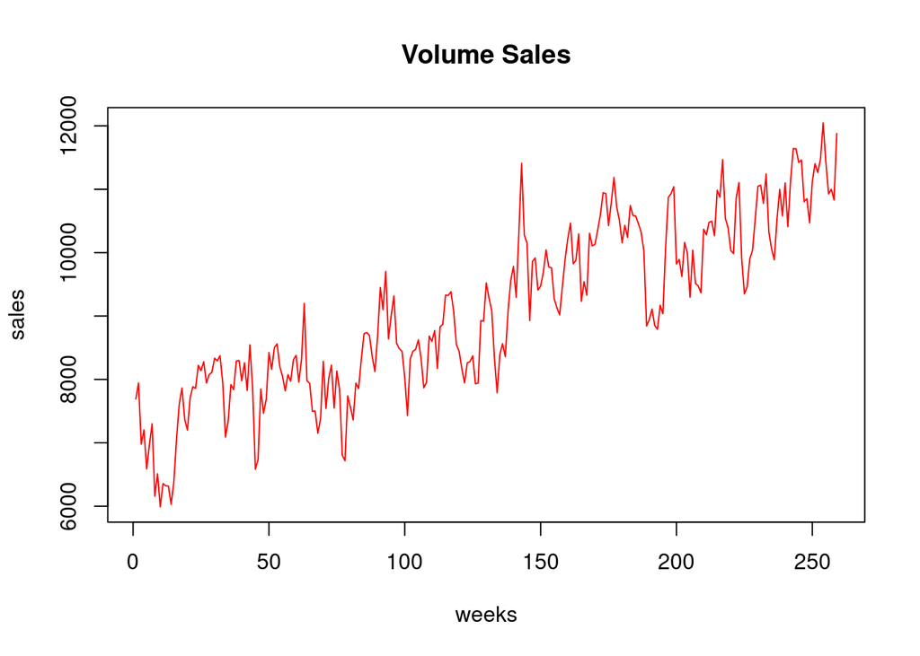

```r
plot(food.df[,c(1)],food.df[,c(11)], type="l", col="red", lwd=1, xlab="weeks", ylab="sales", main="Volume Sales")
```

### **Augmented Dickey-Fuller Test (ADF)**

```r
adf.test(food.df[,c(11)], nlag = 4, output = TRUE)
```

```
## Augmented Dickey-Fuller Test
## alternative: stationary
##
## Type 1: no drift no trend
##      lag   ADF p.value
## [1,]   0 0.124   0.680
## [2,]   1 0.227   0.709
## [3,]   2 0.422   0.765
## [4,]   3 0.496   0.786
## Type 2: with drift no trend
##      lag   ADF p.value
## [1,]   0 -2.73  0.0757
## [2,]   1 -2.28  0.2161
## [3,]   2 -2.16  0.2650
## [4,]   3 -1.94  0.3501
## Type 3: with drift and trend
##      lag   ADF p.value
## [1,]   0 -6.85    0.01
## [2,]   1 -6.35    0.01
## [3,]   2 -5.93    0.01
## [4,]   3 -5.72    0.01
## ----
## Note: in fact, p.value = 0.01 means p.value <= 0.01
```

### **Phillips-Perron Test**

```r
pp.test(food.df[,c(11)], output = TRUE)
```

```
## Phillips-Perron Unit Root Test
## alternative: stationary
##
## Type 1: no drift no trend
##  lag Z_rho p.value
##    5  0.29   0.756
## -----
##  Type 2: with drift no trend
##  lag Z_rho p.value
##    5 -10.4   0.139
## -----
##  Type 3: with drift and trend
##  lag Z_rho p.value
##    5 -81.4    0.01
## ---------------
## Note: p-value = 0.01 means p.value <= 0.01
```

### **Kwiatkowski-Phillips-Schmidt-Shin (KPSS) test**

```r
kpss.test(food.df[,c(11)], output = TRUE)
```

```
## KPSS Unit Root Test
## alternative: nonstationary
##
## Type 1: no drift no trend
##  lag   stat p.value
##    3 0.0503     0.1
## -----
##  Type 2: with drift no trend
##  lag  stat p.value
##    3 0.959    0.01
## -----
##  Type 1: with drift and trend
##  lag  stat p.value
##    3 0.045     0.1
## -----------
## Note: p.value = 0.01 means p.value <= 0.01
##     : p.value = 0.10 means p.value >= 0.10
```